# Lab 3: Mine Crafting

### Part 5, Section B (Forces)

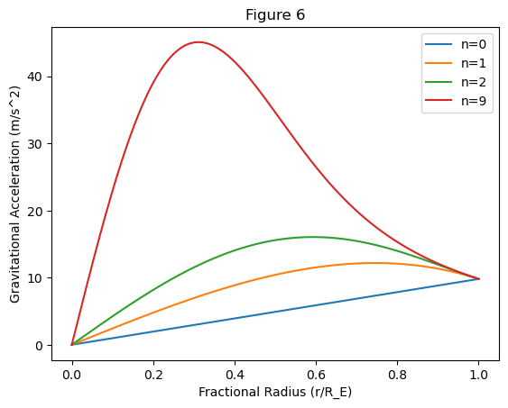

```python
fig6, ax = plt.subplots()
for n in n_vals:
    # Mass enclosed inside radius r
    M_enclosed = np.array([4 * np.pi * rho_n[n] * quad(mass_integrand, 0, r, args=(n,))[0] for r in r_arr])
    # F/m = - GM(r)/r^2
    force = np.zeros_like(r_arr)
    force[1:] = G * M_enclosed[1:] / (r_arr[1:]**2)
    ax.plot(r_arr / R_earth, force, label=f'n={n}')

ax.set_xlabel('Fractional Radius (r/R_E)')
ax.set_ylabel('Gravitational Acceleration (m/s^2)')
ax.set_title('Figure 6')
ax.legend()
```

### Part 5, Section C (Equations of Motion)

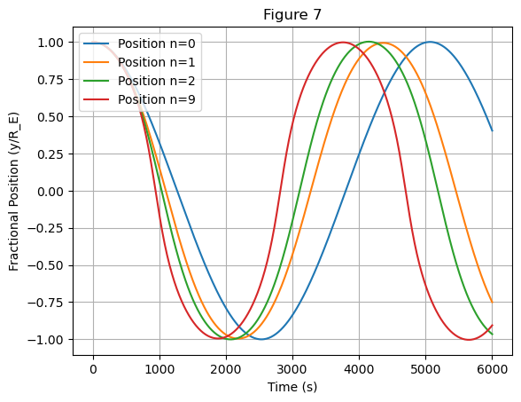

```python
fig7, ax = plt.subplots()
for n in n_vals:
    def ode_non_uniform(t, S):
        y, v = S
        r = np.abs(y)
        if r == 0:
            a = 0
        else:
            M_enc = 4 * np.pi * rho_n[n] * quad(mass_integrand, 0, r, args=(n,))[0]
            a = -np.sign(y) * (G * M_enc / r**2)
        return [v, a]

    sol = solve_ivp(ode_non_uniform, [0, 6000], [R_earth, 0], t_eval=np.linspace(0, 6000, 500))
    ax.plot(sol.t, sol.y[0] / R_earth, label=f'Position n={n}')

ax.set_xlabel('Time (s)')
ax.set_ylabel('Fractional Position (y/R_E)')
ax.set_title('Figure 7')
ax.legend(loc='upper left')
ax.grid()
```

## Part 6: A Lunar Mine Shaft

Finally, with all of the framework in place, consider the case where the the mine shaft is instead dug on the moon.

1. Compute the travel time to the center of the moon in case we dig a pole-to-pole mine shaft, so that we can again avoid the Coriolis force, though on the moon this force is very small. No drag force either, which is actually realistic for the moon!
2. What is the density (if you asssume a constant density) of the moon compared to that of earth?
3. How does the fall/orbit time depend on density? See if you can discover a relationship between the density and the fall time. You should think beyond strictly linear relationships.

This problem can actually be done on paper, and then you can compare the answer with that for the homogenous earth you did in Part 4.

## Part 7: Fourier Transforming Orbits

Take the solutions for n=0 and n=9 of the orbits in Part 5 (the inhomogeneous earth) and Fourier Transform them, to see what frequencies (*1/periods*) are dominant in the power spectra. Comment on what you see.

**Hint:** you could take the orbit from the previous integration in Part 5c, but it is useful to increase the integration time and sampling to get more meaningful smooth enough curves. We discussed this in class.

For an example of a spectral analysis of galactic orbits see https://articles.adsabs.harvard.edu/pdf/1982ApJ...252..308B

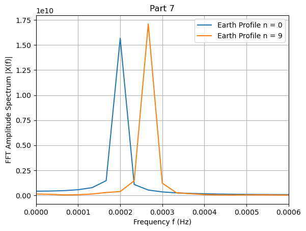

```python
T_max = 30000.0
t_eval = np.linspace(0, T_max, 5000)
dt = t_eval[1] - t_eval[0]  # Sampling interval

fig8, ax = plt.subplots()

# compare the n=0 to n=9
for n in [0, 9]:
    def ode_oscillator(t, S):
        y, v = S
        r = np.abs(y)
        if r == 0:
            return [v, 0.0]
        M_enc, _ = quad(mass_integrand, 0, r, args=(n,))
        M_enclosed = 4 * np.pi * rho_n[n] * M_enc
        return [v, -np.sign(y) * (G * M_enclosed / r**2)]

    sol = solve_ivp(ode_oscillator, [0, T_max], [R_earth, 0], t_eval=t_eval)
    position_data = sol.y[0]

    fft_coeffs = np.fft.rfft(position_data)
    fft_amplitudes = np.abs(fft_coeffs)
    frequencies = np.fft.rfftfreq(len(t_eval), d=dt)

    # plot spectrum for density profile
    ax.plot(frequencies, fft_amplitudes, label=f'Earth Profile n = {n}')

ax.set_xlim(0, 0.0006)
ax.set_xlabel('Frequency f (Hz)')
ax.set_ylabel('FFT Amplitude Spectrum |X(f)|')
ax.set_title('Part 7')
ax.grid()
ax.legend()
```